# D02 · PCA: карта для исследования данных

**Связь со слайдом 2.** Строка таблицы становится точкой с координатами PC1 и PC2. По карте выбираем объекты, возвращаемся к их изображениям и проверяем, действительно ли соседи похожи.

Используем **те же изображения, ID и train/test, что в D01**. Этот ноутбук независим: никаких файлов, заранее сохранённых D01, не требуется. Здесь нет классификатора или алгоритма кластеризации. Известные метки цифр можно наложить только после построения проекции для проверки интерпретации.

**За 5–10 минут:** PCA 2D → строка и точка → соседи в 2D и 64D → восстановление и потерянные различия → необязательная раскраска известными метками.

**Запуск.** Выберите Python-ядро и выполните **Restart Kernel → Run All**. При необходимости установите зависимости в терминале:

```
python -m pip install numpy scipy pandas matplotlib scikit-learn threadpoolctl ipykernel
```

Данные встроены в scikit-learn; после установки сеть не нужна. Рабочий каталог — папка ноутбука; все результаты сохраняются только в `outputs/d02/`.

```python
from pathlib import Path

SEED = 42
TEST_SIZE = 0.25                  # Должно совпадать с D01 для сравнения.
SELECTED_ID = None                # None = первая строка train; можно указать ID из таблицы.
N_NEIGHBORS = 5
SHOW_LABEL_AUDIT = True           # False: не показывать известные цифры на карте.
OUTPUT_DIR = Path("outputs/d02")
```

```python
from pathlib import Path
from time import perf_counter
from datetime import datetime, timezone
import platform
import os
import json
import hashlib
import numpy as np
import pandas as pd
import matplotlib
import matplotlib.pyplot as plt
import sklearn
import scipy
from IPython.display import display, Markdown
from sklearn.datasets import load_digits
from sklearn.model_selection import train_test_split
from sklearn.preprocessing import StandardScaler
from sklearn.decomposition import PCA
from threadpoolctl import threadpool_limits, threadpool_info

# Ограничиваем BLAS одним потоком: маленькая задача и воспроизводимый режим CPU.
thread_limit = threadpool_limits(limits=1)
np.random.seed(SEED)
plt.rcParams.update({"font.family": "DejaVu Sans", "font.size": 11,
                     "figure.dpi": 110, "axes.spines.top": False,
                     "axes.spines.right": False})
OUTPUT_DIR.mkdir(parents=True, exist_ok=True)
started_at = perf_counter()
environment = {
    "seed": SEED, "device": "CPU", "python": platform.python_version(),
    "numpy": np.__version__, "pandas": pd.__version__, "scipy": scipy.__version__,
    "scikit_learn": sklearn.__version__, "matplotlib": matplotlib.__version__,
    "platform": platform.platform(), "machine": platform.machine(),
    "logical_cpus": os.cpu_count(), "blas_threads": 1,
    "run_utc": datetime.now(timezone.utc).isoformat(),
    "blas": [{k: p.get(k) for k in ("internal_api", "version", "num_threads")}
             for p in threadpool_info()],
}
display(pd.Series(environment).to_frame("Среда запуска"))

from scipy.spatial.distance import pdist
from scipy.stats import spearmanr
from sklearn.neighbors import NearestNeighbors
```

|  | Среда запуска |
| --- | --- |
| seed | 42 |
| device | CPU |
| python | 3.12.14 |
| numpy | 2.5.3 |
| pandas | 3.0.6 |
| scipy | 1.18.1 |
| scikit_learn | 1.9.1 |
| matplotlib | 3.11.2 |
| platform | macOS-26.6.2-arm64-arm-64bit |
| machine | arm64 |
| logical_cpus | 10 |
| blas_threads | 1 |
| run_utc | 2026-10-07T05:37:53.364673+00:00 |
| blas | [{'internal_api': 'openmp', 'version': None, '... |

## 1. Те же объекты, то же разбиение

Одна цифра — изображение 8×8 — строка из 64 признаков. Число строк после PCA не меняется. Для связи с D01 воспроизводим разбиение, но в исследовательские графики включаем **только train**. Test оставляем в стороне.

ID сохраняет личность объекта; номер строки после `train_test_split` может измениться. Поэтому мы не называем «нулевой строкой» одно и то же изображение до и после разбиения.

```python
digits = load_digits()
X = digits.data.astype(np.float64)
y = digits.target.copy()
object_ids = np.array([f"digit-{i:04d}" for i in range(len(X))])
all_idx = np.arange(len(X))
train_idx, test_idx = train_test_split(
    all_idx, test_size=TEST_SIZE, random_state=SEED, stratify=y
)
X_train, X_test = X[train_idx], X[test_idx]
y_train, y_test = y[train_idx], y[test_idx]
train_ids, test_ids = object_ids[train_idx], object_ids[test_idx]

assert len(set(object_ids)) == len(X)
assert np.intersect1d(train_idx, test_idx).size == 0
assert np.array_equal(np.sort(np.r_[train_idx, test_idx]), all_idx)
assert len(train_idx) + len(test_idx) == len(X) == 1797
assert X.shape[1] == 64
split_fingerprint = hashlib.sha256(
    np.r_[train_idx, [-1], test_idx].astype("<i8").tobytes()
).hexdigest()[:16]
print(f"Всего: {X.shape}; train: {X_train.shape}; test: {X_test.shape}")
print("Отпечаток разбиения D01/D02:", split_fingerprint)
feature_names = [f"pixel_{r}_{c}" for r in range(8) for c in range(8)]
original_table = pd.DataFrame(X_train, index=train_ids, columns=feature_names)
original_table.index.name = "object_id"

display(original_table.iloc[:8, :8].round(1))
print("Показаны первые 8 из 64 столбцов.")
```

```
Всего: (1797, 64); train: (1347, 64); test: (450, 64)
Отпечаток разбиения D01/D02: 6dc3375408b6b269
```

| object_id | pixel_0_0 | pixel_0_1 | pixel_0_2 | pixel_0_3 | pixel_0_4 | pixel_0_5 | pixel_0_6 | pixel_0_7 |
| --- | --- | --- | --- | --- | --- | --- | --- | --- |
| digit-0730 | 0.0 | 2.0 | 12.0 | 16.0 | 12.0 | 0.0 | 0.0 | 0.0 |
| digit-1590 | 0.0 | 0.0 | 0.0 | 13.0 | 14.0 | 0.0 | 0.0 | 0.0 |
| digit-0313 | 0.0 | 2.0 | 11.0 | 16.0 | 12.0 | 1.0 | 0.0 | 0.0 |
| digit-0987 | 0.0 | 0.0 | 11.0 | 10.0 | 0.0 | 0.0 | 0.0 | 0.0 |
| digit-0094 | 0.0 | 0.0 | 3.0 | 12.0 | 16.0 | 10.0 | 0.0 | 0.0 |
| digit-0767 | 0.0 | 0.0 | 0.0 | 5.0 | 11.0 | 0.0 | 6.0 | 0.0 |
| digit-0404 | 0.0 | 0.0 | 5.0 | 11.0 | 8.0 | 7.0 | 0.0 | 0.0 |
| digit-0015 | 0.0 | 5.0 | 12.0 | 13.0 | 16.0 | 16.0 | 2.0 | 0.0 |

```
Показаны первые 8 из 64 столбцов.
```

## 2. Две координаты вместо 64

PCA выбирает направления с наибольшей дисперсией. После стандартизации и центрирования $A=U\Sigma V^\top$, а координаты карты — $Z=A V_{[:,1:2]}$. Для каждого объекта это ровно два числа.

Оси — линейные комбинации пикселей, а не номера классов. Метки не передаём ни scaler, ни PCA. Масштабирование — явное решение, согласованное с D01; оно делает вклад редких и часто меняющихся пикселей сопоставимым.

```python
scaler = StandardScaler().fit(X_train)
X_train_scaled = scaler.transform(X_train)
pca = PCA(n_components=2, svd_solver="full").fit(X_train_scaled)
Z = pca.transform(X_train_scaled)
projection = pd.DataFrame(Z, index=train_ids, columns=["PC1", "PC2"])
projection.index.name = "object_id"
assert projection.index.equals(original_table.index)
assert Z.shape == (len(train_idx), 2)
np.testing.assert_allclose(scaler.mean_, X_train.mean(axis=0), atol=1e-12)
np.testing.assert_allclose(pca.mean_, X_train_scaled.mean(axis=0), atol=1e-12)
np.testing.assert_allclose(Z.mean(axis=0), 0, atol=1e-12)

selected_id = train_ids[0] if SELECTED_ID is None else SELECTED_ID
if selected_id not in projection.index:
    raise ValueError("SELECTED_ID должен быть ID из train-таблицы выше; test не исследуем.")
selected_pos = int(np.flatnonzero(train_ids == selected_id)[0])
selected_global_idx = int(train_idx[selected_pos])
assert object_ids[selected_global_idx] == selected_id
assert 1 <= N_NEIGHBORS < len(train_idx)
print(f"{X_train.shape} → {Z.shape}; сохранено {pca.explained_variance_ratio_.sum():.1%} дисперсии train")
display(projection.head(8).round(4))
```

```
(1347, 64) → (1347, 2); сохранено 21.6% дисперсии train
```

| object_id | PC1 | PC2 |
| --- | --- | --- |
| digit-0730 | 4.0487 | -1.7632 |
| digit-1590 | 0.0215 | 1.2917 |
| digit-0313 | 5.9488 | -1.8261 |
| digit-0987 | 2.4084 | -2.4658 |
| digit-0094 | -0.0761 | 2.7903 |
| digit-0767 | -6.0344 | 0.8479 |
| digit-0404 | 0.6381 | 1.6031 |
| digit-0015 | 4.0039 | 2.6757 |

## 3. От строки к точке и обратно

На карте выделена выбранная строка, справа — соответствующее исходное изображение. В таблице под графиком можно проверить численное совпадение координат точки и строки. Смена знака одной компоненты зеркально отразила бы карту, сохранив расстояния.

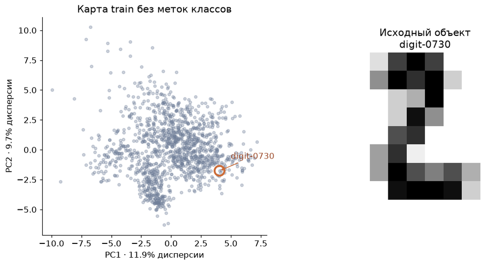

| object_id | pixel_0_0 | pixel_0_1 | pixel_0_2 | pixel_0_3 | pixel_0_4 | pixel_0_5 | PC1 | PC2 |
| --- | --- | --- | --- | --- | --- | --- | --- | --- |
| digit-0730 | 0.0 | 2.0 | 12.0 | 16.0 | 12.0 | 0.0 | 4.0487 | -1.7632 |

```
Пиксели показаны частично; PC1/PC2 — точные координаты выделенной точки.
```

```python
fig, axes = plt.subplots(1, 2, figsize=(10, 4.8), width_ratios=(2.6, 1), layout="constrained")
axes[0].scatter(Z[:, 0], Z[:, 1], s=14, alpha=0.35, color="#71809A", rasterized=True)
axes[0].scatter(*Z[selected_pos], s=170, facecolors="none", edgecolors="#CC6B36", linewidths=2.5)
axes[0].annotate(selected_id, Z[selected_pos], xytext=(15, 16), textcoords="offset points",
                 arrowprops={"arrowstyle": "->", "color": "#CC6B36"}, color="#9C4928")
axes[0].set(xlabel=f"PC1 · {pca.explained_variance_ratio_[0]:.1%} дисперсии",
            ylabel=f"PC2 · {pca.explained_variance_ratio_[1]:.1%} дисперсии",
            title="Карта train без меток классов")
axes[0].set_aspect("equal", adjustable="box")
axes[1].imshow(digits.images[selected_global_idx], cmap="gray_r", vmin=0, vmax=16)
axes[1].set_title(f"Исходный объект\n{selected_id}")
axes[1].set_axis_off()
fig.savefig(OUTPUT_DIR / "01_row_to_point.png", dpi=150)
plt.show()

display(pd.concat([original_table.iloc[[selected_pos], :6],
                   projection.iloc[[selected_pos]]], axis=1).round(4))
print("Пиксели показаны частично; PC1/PC2 — точные координаты выделенной точки.")
```

## 4. Близко на карте — обязательно близко в исходном пространстве?

Сравним ближайших соседей выбранного объекта по евклидову расстоянию в **стандартизованных 64D** и в **PCA 2D**. Это две разные геометрии. Проекция может свести рядом объекты, различающиеся по отброшенным компонентам.

Ортогональная проекция не увеличивает расстояния: $\|z_i-z_j\|\leq\|x_{s,i}-x_{s,j}\|$. Но порядок соседей может измениться. Наше измерение 64D использует масштабированные признаки; оно не претендует на идеальную метрику визуального сходства.

|  | пространство поиска | место | object_id | расстояние_2D | расстояние_64D |
| --- | --- | --- | --- | --- | --- |
| 0 | PCA 2D | 1 | digit-0956 | 0.1514 | 12.4765 |
| 1 | PCA 2D | 2 | digit-0243 | 0.2027 | 6.0722 |
| 2 | PCA 2D | 3 | digit-0436 | 0.3914 | 11.7311 |
| 3 | PCA 2D | 4 | digit-1474 | 0.3919 | 7.4099 |
| 4 | PCA 2D | 5 | digit-1006 | 0.4331 | 9.7333 |
| 5 | Исходные 64D | 1 | digit-0830 | 1.3893 | 4.7819 |
| 6 | Исходные 64D | 2 | digit-0333 | 1.8914 | 5.1611 |
| 7 | Исходные 64D | 3 | digit-0371 | 1.6769 | 5.2127 |
| 8 | Исходные 64D | 4 | digit-0306 | 1.8964 | 5.7071 |
| 9 | Исходные 64D | 5 | digit-0132 | 1.1660 | 5.7727 |

```
Совпадение двух списков ближайших соседей: 0%
```

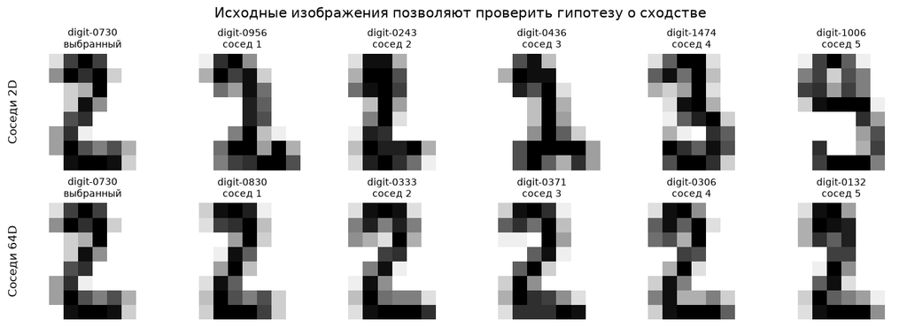

```python
distance_2d = np.linalg.norm(Z - Z[selected_pos], axis=1)
distance_64d = np.linalg.norm(X_train_scaled - X_train_scaled[selected_pos], axis=1)
# Исключаем сам объект по ID, а не по нулевому расстоянию.
other_positions = np.flatnonzero(np.arange(len(train_idx)) != selected_pos)
near_2d = other_positions[np.argsort(distance_2d[other_positions], kind="stable")[:N_NEIGHBORS]]
near_64d = other_positions[np.argsort(distance_64d[other_positions], kind="stable")[:N_NEIGHBORS]]
assert selected_pos not in near_2d and selected_pos not in near_64d
assert np.all(distance_2d <= distance_64d + 1e-10)
neighbor_overlap = len(set(near_2d) & set(near_64d)) / N_NEIGHBORS

neighbor_rows = []
for space, neighbors in [("PCA 2D", near_2d), ("Исходные 64D", near_64d)]:
    for place, pos in enumerate(neighbors, start=1):
        neighbor_rows.append({"пространство поиска": space, "место": place,
                              "object_id": train_ids[pos], "расстояние_2D": distance_2d[pos],
                              "расстояние_64D": distance_64d[pos]})
neighbor_table = pd.DataFrame(neighbor_rows)
display(neighbor_table.round(4))
print(f"Совпадение двух списков ближайших соседей: {neighbor_overlap:.0%}")

fig, axes = plt.subplots(2, N_NEIGHBORS + 1, figsize=(2.0 * (N_NEIGHBORS + 1), 4.2),
                         squeeze=False, layout="constrained")
for row, (name, neighbors) in enumerate([("Соседи 2D", near_2d), ("Соседи 64D", near_64d)]):
    for col, pos in enumerate(np.r_[selected_pos, neighbors]):
        axes[row, col].imshow(X_train[pos].reshape(8, 8), cmap="gray_r", vmin=0, vmax=16)
        axes[row, col].set_title(f"{train_ids[pos]}\n" + ("выбранный" if col == 0 else f"сосед {col}"), fontsize=9)
        axes[row, col].set_axis_off()
    axes[row, 0].text(-0.18, 0.5, name, rotation=90, va="center", ha="center",
                     transform=axes[row, 0].transAxes)
fig.suptitle("Исходные изображения позволяют проверить гипотезу о сходстве", fontsize=13)
fig.savefig(OUTPUT_DIR / "02_neighbors.png", dpi=150)
plt.show()
```

## 5. Что потеряно в двух измерениях

Оценим три разные стороны потери информации: долю дисперсии, совпадение списков соседей и ранговую корреляцию попарных расстояний. Это характеристики проекции, **не метрики качества кластеризации**.

Для скорости корреляцию считаем на фиксированной случайной подвыборке до 300 train-объектов. Восстановление $\widehat X_s=ZV_2^\top+\mu$ показывает, что двух чисел недостаточно, чтобы вернуть исходные изображения.

|  | значение |
| --- | --- |
| сохранённая дисперсия | 0.2159 |
| относительная квадратичная ошибка восстановления | 0.7841 |
| средняя доля сохранённых соседей | 0.0913 |
| Spearman корреляция расстояний | 0.6188 |

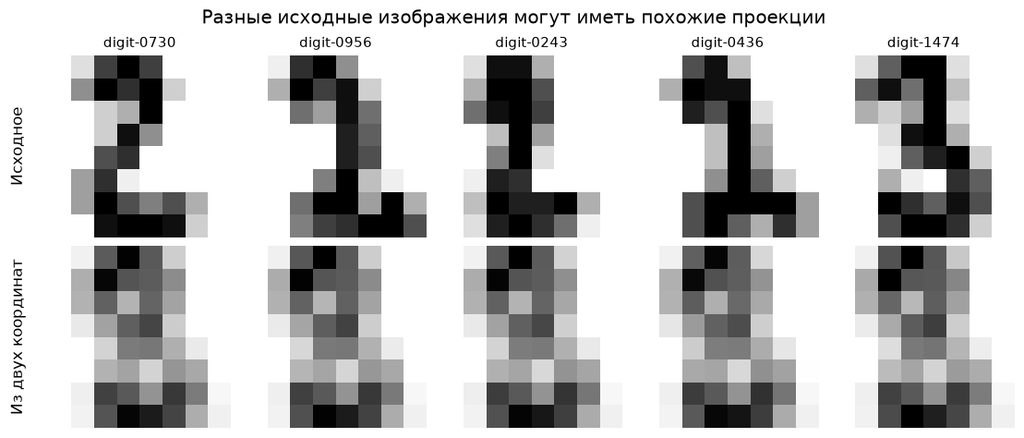

```
Цветовой диапазон общий: 0…16; ограничение яркости действует только при отображении.
```

```python
reconstructed_scaled = pca.inverse_transform(Z)
reconstructed_pixels = scaler.inverse_transform(reconstructed_scaled)
A = X_train_scaled - pca.mean_
relative_error_sq = np.sum((X_train_scaled - reconstructed_scaled) ** 2) / np.sum(A ** 2)
explained_fraction = float(pca.explained_variance_ratio_.sum())
np.testing.assert_allclose(relative_error_sq, 1 - explained_fraction, atol=1e-12)

rng = np.random.default_rng(SEED)
probe_pos = rng.choice(len(X_train), size=min(300, len(X_train)), replace=False)
d64 = pdist(X_train_scaled[probe_pos])
d2 = pdist(Z[probe_pos])
assert np.all(d2 <= d64 + 1e-10)
distance_rank_correlation = float(spearmanr(d64, d2).statistic)

# Наборы соседей для той же подвыборки: исключаем точный индекс запроса.
def neighbor_sets(data, query_positions, count):
    raw = NearestNeighbors(n_neighbors=count + 1).fit(data).kneighbors(
        data[query_positions], return_distance=False
    )
    return [set(row[row != pos][:count]) for pos, row in zip(query_positions, raw)]

sets_64d = neighbor_sets(X_train_scaled, probe_pos, N_NEIGHBORS)
sets_2d = neighbor_sets(Z, probe_pos, N_NEIGHBORS)
mean_neighbor_recall = float(np.mean([len(a & b) / N_NEIGHBORS for a, b in zip(sets_64d, sets_2d)]))
metrics = {"сохранённая дисперсия": explained_fraction,
           "относительная квадратичная ошибка восстановления": float(relative_error_sq),
           "средняя доля сохранённых соседей": mean_neighbor_recall,
           "Spearman корреляция расстояний": distance_rank_correlation}
display(pd.Series(metrics).to_frame("значение").round(4))

show_positions = np.r_[selected_pos, near_2d[:min(4, len(near_2d))]]
fig, axes = plt.subplots(2, len(show_positions), figsize=(2.0 * len(show_positions), 4.2),
                         squeeze=False, layout="constrained")
for col, pos in enumerate(show_positions):
    axes[0, col].imshow(X_train[pos].reshape(8, 8), cmap="gray_r", vmin=0, vmax=16)
    axes[0, col].set_title(train_ids[pos], fontsize=10)
    axes[1, col].imshow(reconstructed_pixels[pos].reshape(8, 8), cmap="gray_r", vmin=0, vmax=16)
    for row in range(2):
        axes[row, col].set_axis_off()
axes[0, 0].text(-0.17, 0.5, "Исходное", rotation=90, va="center", ha="center", transform=axes[0, 0].transAxes)
axes[1, 0].text(-0.17, 0.5, "Из двух координат", rotation=90, va="center", ha="center", transform=axes[1, 0].transAxes)
fig.suptitle("Разные исходные изображения могут иметь похожие проекции", fontsize=13)
fig.savefig(OUTPUT_DIR / "03_information_loss.png", dpi=150)
plt.show()
print("Цветовой диапазон общий: 0…16; ограничение яркости действует только при отображении.")
```

## 6. Необязательная проверка известными метками

Только теперь окрашиваем уже вычисленные координаты по известной цифре. Цвет **не участвовал** в построении PCA и не присваивает кластер: это внешняя подсказка для исследования. Перекрытие классов ожидаемо; большая дисперсия не гарантирует разделение классов. Чтобы оценивать кластеризацию, нужно отдельно задать алгоритм, критерии и протокол проверки.

`SHOW_LABEL_AUDIT=False` скрывает этот шаг. Меняя его, мы не меняем `Z`.

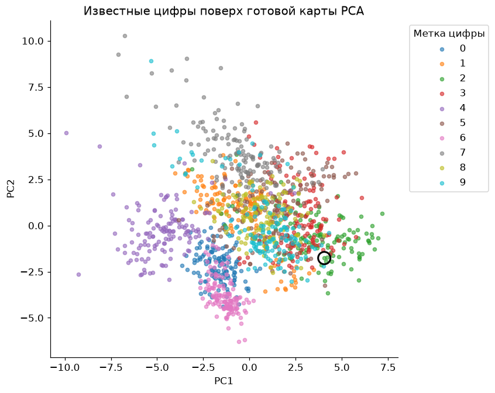

```python
if SHOW_LABEL_AUDIT:
    coordinates_before_audit = Z.copy()
    fig, ax = plt.subplots(figsize=(8, 6), layout="constrained")
    cmap = plt.get_cmap("tab10")
    for label in range(10):
        mask = y_train == label
        ax.scatter(Z[mask, 0], Z[mask, 1], s=16, alpha=0.6,
                   color=cmap(label), label=str(label), rasterized=True)
    ax.scatter(*Z[selected_pos], s=190, facecolors="none", edgecolors="black", linewidths=2)
    ax.set(xlabel="PC1", ylabel="PC2", title="Известные цифры поверх готовой карты PCA")
    ax.set_aspect("equal", adjustable="box")
    ax.legend(title="Метка цифры", bbox_to_anchor=(1.02, 1), loc="upper left")
    fig.savefig(OUTPUT_DIR / "04_label_audit.png", dpi=150)
    plt.show()
    np.testing.assert_array_equal(Z, coordinates_before_audit)
else:
    print("Наложение известных меток отключено; координаты PCA не изменились.")
```

## Вопросы для исследования

1. Выберите другой `SELECTED_ID` из train-таблицы и повторите запуск. Совпадают ли списки соседей в 2D и 64D? Проверяйте изображения, а не только расстояния.
2. Какая доля вариации отсутствует на карте? Почему два похожих положения на карте не гарантируют одинаковые цифры?
3. Сравните StandardScaler с одним центрированием, заменив его на `StandardScaler(with_std=False)`. Как изменится геометрия карты? Это смена метрики признаков, а не «ошибка PCA».
4. Попробуйте три компоненты и сравните сохранение соседей. Новые оси могут вернуть различия, которых нет в 2D.

**Вывод для слайда:** карта помогает выбрать объекты для исследования. Сама карта ещё не доказывает существование классов, кластеров или аномалий.

```python
projection.to_csv(OUTPUT_DIR / "projection_train.csv")
neighbor_table.to_csv(OUTPUT_DIR / "selected_neighbors.csv", index=False)
pd.DataFrame({"object_id": object_ids, "split": np.where(np.isin(all_idx, train_idx), "train", "test")}).to_csv(
    OUTPUT_DIR / "split_ids.csv", index=False
)
report = {"environment": environment, "dataset": "sklearn.load_digits",
          "split_fingerprint": split_fingerprint,
          "n_train": len(train_idx), "n_test": len(test_idx),
          "selected_id": str(selected_id), "n_neighbors": N_NEIGHBORS,
          "label_audit": SHOW_LABEL_AUDIT, "explained_variance_fraction": explained_fraction,
          "reconstruction_relative_squared_error": float(relative_error_sq),
          "selected_neighbor_overlap": neighbor_overlap,
          "mean_neighbor_recall_on_300_objects": mean_neighbor_recall,
          "spearman_pairwise_distances_on_300_objects": distance_rank_correlation,
          "elapsed_seconds": perf_counter() - started_at}
(OUTPUT_DIR / "run_report.json").write_text(json.dumps(report, ensure_ascii=False, indent=2), encoding="utf-8")
print(f"Готово за {report['elapsed_seconds']:.2f} с; результаты: {OUTPUT_DIR.resolve()}")
```

```
Готово за 1.98 с; результаты: /Users/alexey/Documents/projects/life/3. Projects/courses/c01_ModAI/02_linalg/notebooks/applications/outputs/d02
```

## Первичные источники

- [scikit-learn: PCA — определение компонент, transform и inverse_transform](https://scikit-learn.org/stable/modules/generated/sklearn.decomposition.PCA.html).
- [scikit-learn: load_digits — реальные 8×8 изображения и происхождение набора](https://scikit-learn.org/stable/modules/generated/sklearn.datasets.load_digits.html).
- [scikit-learn: StandardScaler — масштаб и сохранённые train-статистики](https://scikit-learn.org/stable/modules/generated/sklearn.preprocessing.StandardScaler.html).

API проверен 7 октября 2026 г. Числа и изображения вычисляются при запуске, а не зашиты в ноутбук; версии окружения и параметры записаны в `run_report.json`.